# TP optimisation

11/12/2023

```python
#1. EZ-ZOURY Taha
#2. BOUALLOU Youness
#3. EL BISSOURI Marouane
#4. LAHBIL Hicham
```

## Introduction :

Dans ce TP, on essaiera d'implementer, from scratch, toute la fonctionnalité des réseaux de neurones, de forward propagation, aux méthodes du gradient, jusqu'au back-propagation. on essaiera d'etudier la capacité des réseaux de neurones dans la régression en experimentant sur deux fonctions chiosis de celles fournies dans le TP et en éxplorant l'influence de plusieurs hypère-paramètres tels que le learning rate, le nombre d'activations dans un layer, la taille du batch, le nombre d'epochs...

On essaiera ensuite d'etudier la capacité des réseaux de neurones dans la classification binaire d'un groupe de points, qu'ils soient croisés entre eux ou non. On essaiera d'évaluer sa robustesse par rapport à l'SVM. On evaluera enfin, le pouvoir des réseaux pour la séparation des points non linéairement séparables.

## 1. Propagation en avant :

### 1.a. Fonctions d'activation :

```python
import numpy as np

def linear(x):
    return x

def relu(x):
    if x<0:
        return 0
    return x

def sigmoid(x):
    return 1/(1+np.exp(-x))

def tanh(x):
    return np.tanh(x)

def linearDeriv(x):
    return 1

def reluDeriv(x):
    if x<0:
        return 0
    return 1

def sigmoidDeriv(x):
    return sigmoid(x)*(1-sigmoid(x))

def tanhDeriv(x):
    return 1-tanh(x)**2
```

### 1.b. Création du réseau :

createRandomWeightsByLayer crée des poids aléatoires pour le réseau de neurones envisagés en donnant le nombre d'activation dans chaque layer.

```python
layerSizes = [5,3,2] # 5 inputs, 3 intermediate neurons (=layer1), 2 outputs (=layer2)


def createRandomWeightsByLayer(layerSizes):
    numberOfLayers = len(layerSizes) - 1
    weightsByLayer = []

    for i in range(numberOfLayers):
        nrows = layerSizes[i] + 1
        ncols = layerSizes[i + 1]

        # Random initialization of weights according to LeCun and Bottou
        # E(weight) = 0, V(weight) = 1 / number_of_inputs
        weights = np.random.normal(loc=0, scale=np.sqrt(1 / nrows), size=(nrows, ncols))
        weightsByLayer.append(weights)

    return weightsByLayer

# Generating random weights for the given layer sizes
random_weights = createRandomWeightsByLayer(layerSizes)

# Displaying the generated random weights for each layer
for i, weights in enumerate(random_weights):
    print(f"Layer {i+1} weights shape: {weights.shape}")
    print(weights)
    print()
```

```
Layer 1 weights shape: (6, 3)
[[ 0.43757694 -0.15992802  0.49304468]
 [ 0.37148383  0.71494483  0.38861488]
 [ 0.02521609 -0.02374332 -0.00264072]
 [-0.07256098 -0.34377809 -0.11615998]
 [-0.40552937 -0.78179844  0.10311698]
 [ 0.04097085 -0.43076552 -0.12103109]]

Layer 2 weights shape: (4, 2)
[[-1.1528982   0.06947659]
 [-0.48702421  0.51252833]
 [-0.94241431  0.00773854]
 [ 0.39438868  0.02755055]]
```

forwardPropagation_1af effectue l'opération feedforward en utilisant des données à l'entrée et des poids données avec une seule fonction d'activation pour chaque layer.

```python
def forwardPropagation_1af(inputs, weightsByLayer, activationFunction):
    numberOfLayers = len(weightsByLayer)
    layer = np.array(inputs)

    for i in range(numberOfLayers):  # propagation for layer number i
        # To model the bias parameters, append 1 to the current layer
        layer = np.append(layer, 1)
        # Calculate the activation of the layer
        layer = activationFunction(np.dot(layer, weightsByLayer[i]))

    return layer
```

```python
np.random.seed(1234)

layerSizes = [5, 3, 2]  # Example layer sizes
Weights = createRandomWeightsByLayer(layerSizes)  # Generate random weights
randomInputs = np.random.uniform(size=layerSizes[0])  # Generate random inputs

result = forwardPropagation_1af(randomInputs, Weights, sigmoid)  # Perform forward propagation
print("Result after forward propagation:", result)
```

```
Result after forward propagation: [0.74171768 0.35829471]
```

Cette fonction effectue la même opération mais en précisant une fonction d'activation pour chaque unité dans chaque layer.

```python
def forwardPropagation(inputs, weightsByLayer, activationFunctionsByLayer):
    numberOfLayers = len(weightsByLayer)
    dimOut = weightsByLayer[numberOfLayers - 1].shape[1]  # Number of output dimensions
    nbdata = inputs.shape[1]  # Number of input data samples
    y = np.zeros((dimOut, nbdata))  # Output matrix

    for idata in range(nbdata):
        layer = inputs[:, idata].reshape(-1, 1)  # Get input data for each sample

        for i in range(numberOfLayers):  # Forward propagation for each layer
            layer = np.vstack((layer, np.array([[1]])))  # Append bias parameter to the previous layer's output
            layer = np.dot(weightsByLayer[i].T, layer)
            numberOfNeurons = weightsByLayer[i].shape[1]

            for j in range(numberOfNeurons):  # Apply activation function to each neuron
                layer[j] = activationFunctionsByLayer[i][j](layer[j])

        y[:, idata] = layer.flatten()  # Assign the final layer output to y

    return y
```

```python
layerSizes = [5, 3, 2]  # Example layer sizes
Weights = createRandomWeightsByLayer(layerSizes)  # Generate random weights

# Generate random inputs
randomInputs = np.random.uniform(size=(layerSizes[0], 1))

# Define activation functions for each layer and neuron
activationFunctionsByLayer = [
    [sigmoid, relu, sigmoid],
    [sigmoid, relu, relu],
    [sigmoid, sigmoid]
]

# Perform forward propagation
result = forwardPropagation(randomInputs, Weights, activationFunctionsByLayer)
print("Result after forward propagation:", result)
```

```
Result after forward propagation: [[0.50322112]
 [0.27776589]]
```

### 1e. Créer des réseaux de neurones et faire quelques exemples de propagations avant.

```python
layerSizes = [2,1,1]
Weights = createRandomWeightsByLayer(layerSizes)
randomInputs = np.random.uniform(size=(layerSizes[0], 1))
activationFunctionsByLayer = [
    [sigmoid],
    [linear],
]
result = forwardPropagation(randomInputs, Weights, activationFunctionsByLayer)
print("Result after forward propagation:", result)
```

```
Result after forward propagation: [[-0.49652055]]
```

On sort du régime linéraire du sigmoid en augmentant les poids initiaux.

```python
Weights= [Weights[i]+3 for i in range(len(Weights))]
result = forwardPropagation(randomInputs, Weights, activationFunctionsByLayer)
print("Result after forward propagation:", result)
```

```
Result after forward propagation: [[5.33977002]]
```

Visualisons ces résultats:

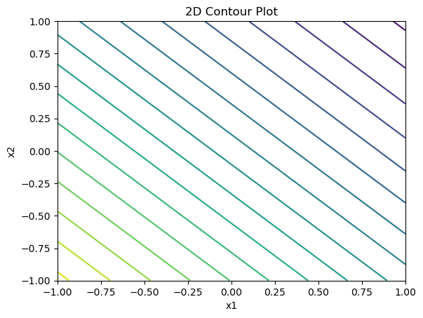

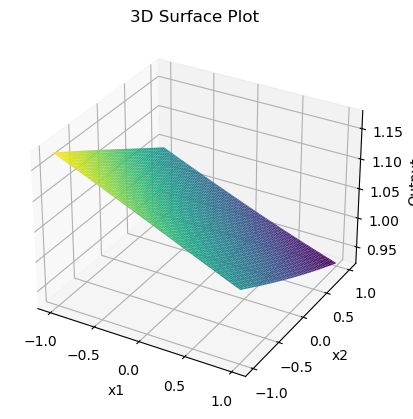

```python
import matplotlib.pyplot as plt
from mpl_toolkits.mplot3d import Axes3D
Weights = createRandomWeightsByLayer(layerSizes)

no_grid = 100

LB = np.array([-1, -1])
UB = np.array([1, 1])
x1 = np.linspace(LB[0], UB[0], no_grid)
x2 = np.linspace(LB[1], UB[1], no_grid)
X1, X2 = np.meshgrid(x1, x2)
dataInputs = np.vstack([X1.ravel(), X2.ravel()]).T
dataOutputs=[]
for i in range(dataInputs.shape[0]):
    dataOutputs.append(forwardPropagation(dataInputs[i].reshape((2,1)), Weights, activationFunctionsByLayer))
dataOutputs_grid = np.array(dataOutputs).reshape(X1.shape)

plt.contour(X1, X2, dataOutputs_grid, levels=20)
plt.xlabel("x1")
plt.ylabel("x2")
plt.title("2D Contour Plot")
plt.show()

# 3D plot
fig = plt.figure()
ax = fig.add_subplot(111, projection='3d')
ax.plot_surface(X1, X2, dataOutputs_grid, cmap='viridis')
ax.set_xlabel('x1')
ax.set_ylabel('x2')
ax.set_zlabel('Output')
ax.set_title('3D Surface Plot')
plt.show()
```

Puisque les poids sont faibles et la sortie est la sigmoid d'une somme pondérée de x1 et x2, on reste dans le régime linéaire de la sigmoide d'ou la linéarité de la sortie.

Essayons avec des weights plus elevés.

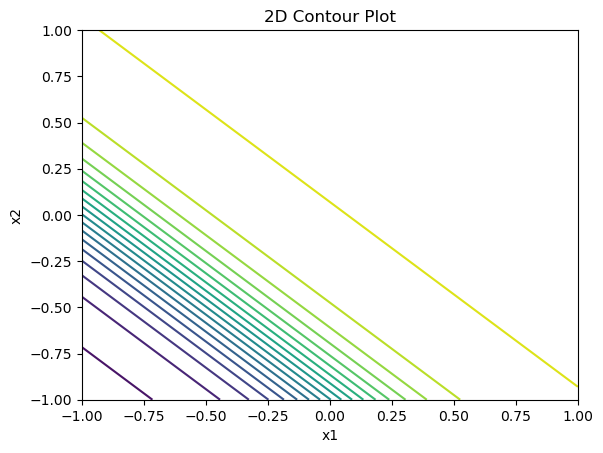

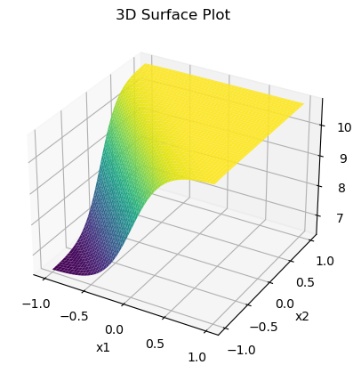

```python
Weights= [Weights[i]+5 for i in range(len(Weights))]
dataOutputs=[]
for i in range(dataInputs.shape[0]):
    dataOutputs.append(forwardPropagation(dataInputs[i].reshape((2,1)), Weights, activationFunctionsByLayer))
dataOutputs_grid = np.array(dataOutputs).reshape(X1.shape)

plt.contour(X1, X2, dataOutputs_grid, levels=20)
plt.xlabel("x1")
plt.ylabel("x2")
plt.title("2D Contour Plot")
plt.show()

# 3D plot
fig = plt.figure()
ax = fig.add_subplot(111, projection='3d')
ax.plot_surface(X1, X2, dataOutputs_grid, cmap='viridis')
ax.set_xlabel('x1')
ax.set_ylabel('x2')
ax.set_zlabel('Output')
ax.set_title('3D Surface Plot')
plt.show()
```

Tandis que pour des poids plus élevés la coube sigmoid de la sortie dans 3D se contracte autour de (0,0), c'est pour cela que la sortie a une telle courbe en 3D.

La fonction Sigmoid, bien que tanh, ont les mêmes propriétés, et servent majoritairememt dans les problèmes de classification multiple. Cependant leurs utilisations est désagréable dans les problèmes de réseaux à plusieurs pramètres (plusieurs couches/activations) (sur tout les réseaux convolutionnels) puisque leurs dérivée s'annulle rapidement lorsqu'on se dévie du 0 (comme le montre la figure ci-dessous). Avec une multiplication de plusieurs scalaires proches de 0 les poids ne subiront presque aucun changement en back-propagation, ce phénomène est connue sous le nom de "Vanishing Gradient". Pour faire face à ce problème, on définie un taux d'activations dans le réseau qui seront utilisés pour calculer la nouvelle valeur des poids.

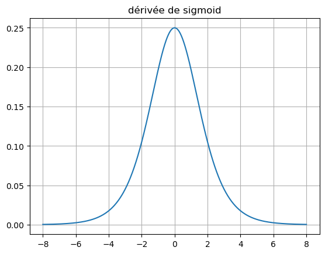

```python
x= np.linspace(-8,8,1000)
dsigmoid= np.exp(-x)/(1+np.exp(-x))**2 # dérivée de la sigmoid
plt.plot(x, dsigmoid)
plt.grid()
plt.title("dérivée de sigmoid")
plt.show()
```

## 2. Rétro-propagation

### 2a. Fonction coût et utilitaires associés

La fonction suivante convertit une liste x en liste des poids par chaque layer.

On fait une simulation du calcul du square loss.

```python
def xtoWeightsByLayer(x, layer_sizes):
    number_of_layers = len(layer_sizes) - 1
    weights_by_layer = []
    filled_up_to = 0

    for i in range(number_of_layers):
        nrows = layer_sizes[i] + 1  # Adding 1 for bias
        ncols = layer_sizes[i + 1]
        istart = filled_up_to
        iend = filled_up_to + nrows * ncols
        filled_up_to = iend
        weights_by_layer.append(x[istart:iend].reshape(nrows, ncols))

    return weights_by_layer

# reverse operation
def weightsByLayerToX(weightsByLayer):
    return np.concatenate([np.hstack(weightsByLayer[i]) for i in range(len(weightsByLayer))])
```

```python
#a definir: x, layerSizes, inputs, activationFunctionsByLayer, dataOutputs

def squareLoss(x):
    weights= xtoWeightsByLayer(x, layer_sizes= layerSizes)
    pred= forwardPropagation(dataInputs, weights, activationFunctionsByLayer)
    return 0.5 * np.sum((pred- dataOutputs)**2)
```

```python
layerSizes= [2,4,2]
activationFunctionsByLayer= [
    [sigmoid, sigmoid, relu, relu],
    [linear, linear]
]
Weights = createRandomWeightsByLayer(layerSizes)
dataInputs = np.random.uniform(size=(layerSizes[0], 1))
dataOutputs = np.arange(1,layerSizes[-1]+1).reshape((layerSizes[-1],1))
x= weightsByLayerToX(Weights)
squareLoss(x)
```

```
2.1215913873737056
```

### 2b. Rétro-propagation

On définit la dérivée de la fonction perte.

```python
def squareLossDeriv(pred, y):
    return pred-y
```

```python
# Activation functions and their derivatives
def sigmoid(x):
    return 1 / (1 + np.exp(-x))

def sigmoidDeriv(x):
    return sigmoid(x) * (1 - sigmoid(x))

def relu(x):
    return np.maximum(0, x)

def reluDeriv(x):
    return (x > 0) * 1.0

def linear(x):
    return x

def linearDeriv(x):
    return 1

# Derivative of the square loss function
def squareLossDeriv(pred, y):
    return (pred - y).T

# Function to create random weights for each layer
def createRandomWeightsByLayer(layerSizes):
    numberOfLayers = len(layerSizes) - 1
    weightsByLayer = []

    for i in range(numberOfLayers):
        nrows = layerSizes[i] + 1  # +1 for bias
        ncols = layerSizes[i + 1]

        # Random initialization of weights
        weights = np.random.normal(loc=0, scale=np.sqrt(1 / nrows), size=(nrows, ncols))
        weightsByLayer.append(weights)

    return weightsByLayer

#------------------------------------

# Backpropagation function
def backPropagation(dataIn, dataOut, weightsByLayer, actFunc, actFuncDeriv, lossDeriv=squareLossDeriv):
    nOutLayer = dataOut.shape[0]
    weightsByLayer = weightsByLayer.copy()
    weightsByLayer.append(np.vstack((np.eye(nOutLayer), np.zeros(nOutLayer))))  # Adding identity layer for bias
    numberOfLayers = len(weightsByLayer)

    A = [None] * numberOfLayers
    Z = [None] * numberOfLayers

    # Forward propagation
    for i in range(numberOfLayers):
        if i == 0:
            A[i] = np.vstack((dataIn, 1))  # Adding bias term
        else:
            A[i] = np.array([actFunc[i - 1][j](Z[i - 1][j, 0]) for j in range(len(actFunc[i - 1]))])
            A[i] = np.vstack((A[i].reshape(-1, 1), 1))  # Adding bias term

        Z[i] = weightsByLayer[i].T @ A[i]

    # Backward propagation
    delta = lossDeriv(Z[-1], dataOut)
    dloss_dweight = [None] * (numberOfLayers - 1)

    for i in reversed(range(1, numberOfLayers)):
        Nbneurons = len(Z[i - 1])
        D = np.array([actFuncDeriv[i - 1][j](Z[i - 1][j, 0]) for j in range(Nbneurons)])
        delta = delta @ weightsByLayer[i].T @ np.vstack((np.diag(D), np.zeros(Nbneurons)))
        dloss_dweight[i - 1] = A[i - 1] @ delta

    dloss_dtheta = np.concatenate([dweight.flatten() for dweight in dloss_dweight if dweight is not None])

    return Z[-1], dloss_dtheta

# the neural network structure and initializing weights
layerSizes = [2, 3, 4, 2]
weights_by_layer = createRandomWeightsByLayer(layerSizes)

# Random input and output data for testing
data_in = np.random.uniform(size=(layerSizes[0], 1))
data_out = np.arange(1, layerSizes[-1] + 1).reshape(-1, 1)# random output

# Activation functions and derivatives for each layer
act_func = [
    [sigmoid, sigmoid, relu],
    [sigmoid, sigmoid, relu, relu],
    [linear, linear]
]

act_func_deriv = [
    [sigmoidDeriv, sigmoidDeriv, reluDeriv],
    [sigmoidDeriv, sigmoidDeriv, reluDeriv, reluDeriv],
    [linearDeriv, linearDeriv]
]

# Running the backpropagation function
Z_last, gradients = backPropagation(data_in, data_out, weights_by_layer, act_func, act_func_deriv)
Z_last, gradients
```

```
(array([[0.83850093],
        [0.41266553]]),
 array([ 0.02697859,  0.01046274, -0.07383495,  0.02521537,  0.00977894,
        -0.06900936,  0.02833304,  0.01098802, -0.0775418 ,  0.01609363,
        -0.05431466, -0.10164587,  0.        ,  0.01984054, -0.06696014,
        -0.12531096,  0.        ,  0.05842543, -0.19718089, -0.36900949,
         0.        ,  0.03468531, -0.11706001, -0.21906917,  0.        ,
        -0.0205888 , -0.20236222, -0.07442297, -0.73148502, -0.01642352,
        -0.16142268,  0.        ,  0.        , -0.16149907, -1.58733447]))
```

Dans la seconde array, il s'agit de la dérivée de la square loss par rapport à chaque weight, sa longueur est de 3x3+4x4+5x2 =35.

Essayons de calculer la dérivée de L par différences finis avec un pas constant h pour chacun des paramètres.

```python
def f_gradf(x, f, h=1.e-8):
    d = len(x)
    result = {'fofx': f(x), 'gradf': [None] * d}
    for i in range(d):
        xp = x.copy()
        xp[i] += h
        result['gradf'][i] = (f(xp) - result['fofx']) / h
    return result
```

```python
# on essaie de flatten la matrice des poids
x = weightsByLayerToX(weightsByLayer = weights_by_layer)
x
```

```
array([ 0.16812749,  0.32708838,  0.29074884,  0.16471554,  0.27960387,
        0.78720642, -0.45097135, -0.27021013,  0.70700833, -0.64055414,
        0.43773775, -0.85535766, -0.22538255,  0.3745819 , -0.10196643,
       -0.09108771,  0.340328  , -0.9092495 ,  0.02353582,  0.1974221 ,
       -0.12421603, -0.30885332, -0.341442  ,  0.2181288 , -0.85150639,
        0.17607273, -0.21436021, -0.13372415,  0.31041243,  0.30349242,
        0.1071327 ,  0.0676306 ,  0.36498319,  0.84681436,  0.28605247])
```

```python
activationFunctionsByLayer= act_func
def squareLoss(x):
    weights= xtoWeightsByLayer(x, layer_sizes= layerSizes)
    pred= forwardPropagation(dataInputs, weights, activationFunctionsByLayer)
    return  0.5 * np.sum((pred- dataOutputs)**2)
```

```python
fdiff = f_gradf(x=x,f=squareLoss)
fdiff
```

```
{'fofx': 1.3258388199300877,
 'gradf': [0.008913825233491934,
  0.004607136894207997,
  -0.033731861748265146,
  0.004676770082312487,
  0.0024171997736743833,
  -0.017697998622168143,
  0.025613777765443047,
  0.013238543594695784,
  -0.09692806557382028,
  0.022394619492160928,
  -0.048791060081043724,
  -0.09252725252650862,
  0.0,
  0.025849455909110475,
  -0.05631812793893687,
  -0.10680158979425869,
  0.0,
  0.05194678021069876,
  -0.11317626835705141,
  -0.21462722710197113,
  0.0,
  0.054570126195585544,
  -0.11889178530566369,
  -0.2254661568557026,
  0.0,
  -0.0378513220766763,
  -0.35788558783167446,
  -0.07762177567371964,
  -0.7339168162090459,
  -0.0020362600494649996,
  -0.01925291037707666,
  0.0,
  0.0,
  -0.17127013141049474,
  -1.6193653751273018]}
```

```python
np.array(fdiff['gradf'])- gradients
```

```
array([-0.01806477, -0.00585561,  0.04010309, -0.0205386 , -0.00736174,
        0.05131136, -0.00271927,  0.00225052, -0.01938626,  0.00630099,
        0.0055236 ,  0.00911862,  0.        ,  0.00600892,  0.01064201,
        0.01850937,  0.        , -0.00647865,  0.08400462,  0.15438226,
        0.        ,  0.01988481, -0.00183178, -0.00639699,  0.        ,
       -0.01726252, -0.15552337, -0.00319881, -0.0024318 ,  0.01438726,
        0.14216977,  0.        ,  0.        , -0.00977107, -0.03203091])
```

Essayons maintenant d'effectuer la descente de gradient au poids, en déterminant le learning rate convenable.

```python
def forwardPropagation(inputs, weightsByLayer, activationFunctionsByLayer):
    numberOfLayers = len(weightsByLayer)
    dimOut = weightsByLayer[numberOfLayers - 1].shape[1]  # Number of output dimensions
    nbdata = inputs.shape[1]  # Number of input data samples
    y = np.zeros((dimOut, nbdata))  # Output matrix

    for idata in range(nbdata):
        layer = inputs[:, idata].reshape(-1, 1)  # Get input data for each sample

        for i in range(numberOfLayers):  # Forward propagation for each layer
            layer = np.vstack((layer, np.array([[1]])))  # Append bias parameter to the previous layer's output
            layer = np.dot(weightsByLayer[i].T, layer)
            numberOfNeurons = weightsByLayer[i].shape[1]

            for j in range(numberOfNeurons):  # Apply activation function to each neuron
                layer[j] = activationFunctionsByLayer[i][j](layer[j])

        y[:, idata] = layer.flatten()  # Assign the final layer output to y

    return y
```

On commence par un learning rate générique de $10^{-2}$.

```python
lr=1e-2
grad_index = 0
reshaped_gradients = []
for weight_matrix in weights_by_layer:
    nrows, ncols = weight_matrix.shape
    reshaped_grad = gradients[grad_index:grad_index + nrows * ncols].reshape(nrows, ncols)
    reshaped_gradients.append(reshaped_grad)
    grad_index += nrows * ncols
new_weights= [weights_by_layer[i] - lr * reshaped_gradients[i] for i in range(len(weights_by_layer))]
new_weights
```

```
[array([[ 0.16785771,  0.32698375,  0.29148719],
        [ 0.16446339,  0.27950608,  0.78789651],
        [-0.45125468, -0.27032001,  0.70778375]]),
 array([[-0.64071507,  0.4382809 , -0.8543412 , -0.22538255],
        [ 0.3743835 , -0.10129683, -0.0898346 ,  0.340328  ],
        [-0.90983375,  0.02550763,  0.2011122 , -0.12421603],
        [-0.30920018, -0.3402714 ,  0.22031949, -0.85150639]]),
 array([[ 0.17627862, -0.21233659],
        [-0.13297992,  0.31772728],
        [ 0.30365665,  0.10874692],
        [ 0.0676306 ,  0.36498319],
        [ 0.84842935,  0.30192581]])]
```

```python
forwardPropagation(data_in, new_weights, act_func)
```

```
array([[0.84336062],
       [0.433921  ]])
```

```python
# square loss sum avant
0.5*np.sum((data_out-forwardPropagation(data_in, weights_by_layer, act_func)))
```

```
0.8744167678356793
```

```python
# square loss sum après
0.5*np.sum((data_out-forwardPropagation(data_in, new_weights, act_func)))
```

```
0.8613591889276362
```

Notre descente de gradient a bien réussi à réduire la somme des carrés des erreurs.

Il faut noter qu'on peut aussi adapter d'autres fonctions de pertes tel que la somme des valeurs absolus d'erreurs...

Essayons maintenant, par cross validation, de trouver le learning rate $\alpha \in [0,1]$ qui minimise bien notre fonction d'erreur.

```python
learning_rates = [0.1, 0.01, 0.001, 0.0001]
sum_square= np.inf
lr_opt= 1
for lr in learning_rates:
    grad_index = 0
    reshaped_gradients = []
    for weight_matrix in weights_by_layer:
        nrows, ncols = weight_matrix.shape
        reshaped_grad = gradients[grad_index:grad_index + nrows * ncols].reshape(nrows, ncols)
        reshaped_gradients.append(reshaped_grad)
        grad_index += nrows * ncols
    new_weights= [weights_by_layer[i] - lr * reshaped_gradients[i] for i in range(len(weights_by_layer))]
    ss= 0.5*np.sum((data_out-forwardPropagation(data_in, new_weights, act_func)))
    if ss<sum_square:
        sum_square=ss
        lr_opt=lr
print("learning rate optimale :", lr_opt)
print("sum_square minimale :", sum_square)
```

```
learning rate optimale : 0.1
sum_square minimale : 0.7424458101228069
```

Vu le nombre faible d'échantillons, on s'est basé sur une descente de gradient déterministe dans ce cas, on essaiera plus tard pour des échantillons plus grands d'explorer la descente de gradient à mini-batch puis stochastique.

## 3. Creation des données à apprendre

Les fonctions qu'on peut utiliser:

```python
import numpy as np

def ackley(xx, get_glob_xstar=False, a=20, b=0.2, c=2*np.pi):
    glob_xstar = np.zeros_like(xx)
    if get_glob_xstar:
        return glob_xstar
    else:
        xx = xx - glob_xstar
        aa = 6.4 * xx
        d = len(aa)
        sum_val = -a * np.exp(-b * np.sqrt((1/d) * np.sum(aa**2))) - np.exp((1/d) * np.sum(np.cos(c * aa))) + a + np.exp(1)
        return sum_val

def rastrigin(xx, get_glob_xstar=False):
    glob_xstar = np.zeros_like(xx)
    if get_glob_xstar:
        return glob_xstar
    else:
        scaling_fact = 1.024
        xx = xx - glob_xstar
        aa = scaling_fact * xx
        d = len(aa)
        sum_val = np.sum(aa**2 - 10 * np.cos(2 * np.pi * aa)) + 10 * d
        return sum_val

def schwefel(xx, get_glob_xstar=False):
    glob_xstar = np.full_like(xx, 3.209687)
    if get_glob_xstar:
        return glob_xstar
    else:
        xx = xx + 1
        aa = 100 * xx
        d = len(aa)
        sum_val = 418.9829 * d - np.sum(aa * np.sin(np.sqrt(np.abs(aa))))
        return sum_val

def sphere(xx, get_glob_xstar=False):
    d = len(xx)
    glob_xstar = np.arange(1, d + 1)
    if get_glob_xstar:
        return glob_xstar
    else:
        aa = xx - glob_xstar
        return np.sum(aa**2)

def michalewicz(xx, get_glob_xstar=False, m=10):
    if get_glob_xstar:
        return np.full_like(xx, np.nan)
    else:
        aa = 0.1 * np.pi * (xx + 5)
        d = len(aa)
        i = np.arange(1, d + 1)
        sum_val = np.sum(np.sin(aa) * np.sin((i * aa**2) / np.pi)**(2 * m))
        return -sum_val + 2

def quadratic(xx, cond_no=20, get_glob_xstar=False):
    glob_xstar = np.zeros_like(xx)
    if get_glob_xstar:
        return glob_xstar
    else:
        aa = 1.024 * xx
        d = len(aa)
        lambdas = np.diag(np.linspace(1, cond_no, d))
        np.random.seed(1)  # Change seed to change orientation
        glob_umat = np.linalg.qr(np.random.rand(d, d))[0]
        glob_umat = glob_umat[:, np.random.choice(d, d, replace=False)]
        H = glob_umat @ lambdas @ glob_umat.T
        return 0.5 * (aa - glob_xstar).T @ H @ (aa - glob_xstar)

def quadratic_ill(xx, get_glob_xstar=False):
    return quadratic(xx, cond_no=10000, get_glob_xstar=get_glob_xstar)

def tunnel(xx, get_glob_xstar=False, b=0.5):
    glob_xstar = np.zeros_like(xx)
    if get_glob_xstar:
        return glob_xstar
    else:
        d = len(xx)
        xx = xx - glob_xstar
        if d > 1:
            in_tunnel = all(np.logical_and(xx[1:] > -b, xx[1:] < b))
            if in_tunnel:
                return -np.exp(-np.linalg.norm(xx) / 10)
            else:
                return xx.T @ xx
        else:
            return xx**2

def quad_wave(xx, get_glob_xstar=False):
    if get_glob_xstar:
        return np.full_like(xx, np.nan)
    else:
        cond_no = 1.e1
        d = len(xx)
        lambdas = np.diag(np.linspace(1, cond_no, d))
        glob_umat = np.eye(d)
        H = glob_umat @ lambdas @ glob_umat.T
        return 1 + 0.5 * xx.T @ H @ xx - 0.2 * np.sum(np.cos(4 * np.pi * xx[:2]))

def L1norm(xx, get_glob_xstar=False):
    if get_glob_xstar:
        return np.zeros_like(xx)
    else:
        return np.sum(np.abs(xx))

def rosen(xx, get_glob_xstar=False):
    if get_glob_xstar:
        return np.ones_like(xx)
    else:
        d = len(xx)
        xi = xx[:-1]
        xnext = xx[1:]
        return np.sum(100 * (xnext - xi**2)**2 + (xi - 1)**2)
```

on essaie de normer nos données entre -1 et 1 de la façon suivante: $$x_n= 2*\frac{x-xmin}{xmax-xmin}-1$$.
Tel que xmin(resp xmax) le minimum(resp. maximum) de chaque colonne de la matrice des données X.

```python
def normByRow(X):
    nr, nc = X.shape
    Xnorm = np.zeros((nr, nc))
    minAndMax = np.zeros((nc, 2))

    for i in range(nc):
        zmin = np.min(X[:, i])
        zmax = np.max(X[:, i])
        minAndMax[i, :] = [zmin, zmax]
        Xnorm[:, i] = 2 * (X[:, i] - zmin) / (zmax - zmin) - 1

    return {'dat': Xnorm, 'minAndMax': minAndMax}

def unnormByRow(normDat):
    nr, nc = normDat['dat'].shape
    X = np.zeros((nr, nc))

    for i in range(nc):
        zmin = normDat['minAndMax'][i, 0]
        zmax = normDat['minAndMax'][i, 1]
        X[:, i] = (normDat['dat'][:, i] + 1) / 2 * (zmax - zmin) + zmin

    return X
```

Essayons de génerer des données train et test.

```python
d = 2
LB = -5 * np.ones(d)
UB = 5 * np.ones(d)
ntrain = 100
ntest = 15
ndata = ntrain + ntest

np.random.seed(1)
rawX = np.random.uniform(low=LB, high=UB, size=(ndata, d))


rawYobs = np.apply_along_axis(quadratic, 1, rawX)

# normalize the data
X = normByRow(rawX)
Yobs = normByRow(rawYobs.reshape(-1, 1))

# Split into training and testing sets
itrain = np.arange(ntrain)
itest = np.arange(ntrain, ndata)
Xtrain = X['dat'][itrain, :].T
Xtest = X['dat'][itest, :].T
Ytrain = Yobs['dat'][itrain, :].T
Ytest = Yobs['dat'][itest, :].T
```

```python
Xtest.shape
```

```
(2, 15)
```

il s'agit ici d'un problème de régression, on va essayer d'entrainer, puis améliorer un modèle qui achève le mieux une approximation de la fonction quadratic.

Avant tout essayons de visualiser cette fonction.

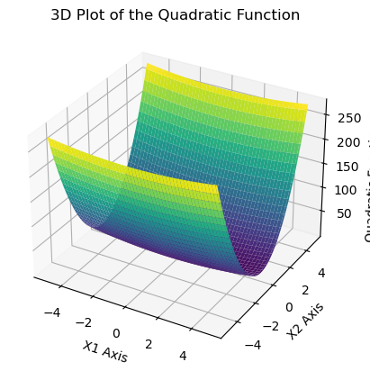

```python
import matplotlib.pyplot as plt
from mpl_toolkits.mplot3d import Axes3D

def quadratic(xx, cond_no=20, get_glob_xstar=False):
    glob_xstar = np.zeros_like(xx)
    if get_glob_xstar:
        return glob_xstar
    else:
        aa = 1.024 * xx
        d = len(aa)
        lambdas = np.diag(np.linspace(1, cond_no, d))
        np.random.seed(1)
        glob_umat = np.linalg.qr(np.random.rand(d, d))[0]
        glob_umat = glob_umat[:, np.random.choice(d, d, replace=False)]
        H = glob_umat @ lambdas @ glob_umat.T
        return 0.5 * (aa - glob_xstar).T @ H @ (aa - glob_xstar)

# Create a meshgrid of input values
x = np.linspace(-5, 5, 100)
y = np.linspace(-5, 5, 100)
x1, x2 = np.meshgrid(x, y)

# Compute the function values
z = np.array([quadratic(np.array([x, y])) for x, y in zip(np.ravel(x1), np.ravel(x2))])
z = z.reshape(x1.shape)

# Plot
fig = plt.figure()
ax = fig.add_subplot(111, projection='3d')
ax.plot_surface(x1, x2, z, cmap='viridis')

ax.set_xlabel('X1 Axis')
ax.set_ylabel('X2 Axis')
ax.set_zlabel('Quadratic Function Value')

plt.title('3D Plot of the Quadratic Function')
plt.show()
```

D'apès le "Universal Approximation Theorem", on peut modéliser toute fonction continue sur un compacte de $\mathbb{R}^n$ avec un neural network par un seul hidden layer. Cependant, pour des fonctions irrégulières, un seul hidden layer n'est pas suffisant et on aura besoin besoin de plusieurs layers pour s'en countourner. En fait, nous pouvons approximer de nombreuses fonctions de manière beaucoup plus compacte en utilisant des réseaux plus profonds (plutôt que plus larges // cad avec plus de layers plutot qu'avec un nombre élevé d'activations) (Simonyan et Zisserman, 2014).

Dans notre cas, la fonction quadratic en dimension 2, on se limitera à un réseau à un seul layer pour apprendre la fonction en essayant de coder un optimiseur deterministe adapté, puis on se pointera sur le choix de nombre d'epochs, le nombre d'activation du hidden layer , et le learning rate pour améliorer notre modèle.

Il faut noter au dessus qu'on a crée des données 2d rawX, on a ensuite appliqué la fonction quadratic pour avoir rawY. On a normalisé ces deux derniers puis on les a divisé en données train et test.

On essaie d'ajuster nos fonctions backpropagation et forwardPropagation pour ce problème

```python
def createRandomWeightsByLayer(layerSizes):
    numberOfLayers = len(layerSizes) - 1
    weightsByLayer = []

    for i in range(numberOfLayers):
        nrows = layerSizes[i] + 1  # +1 for bias
        ncols = layerSizes[i + 1]
        weights = np.random.normal(loc=0, scale=np.sqrt(1 / nrows), size=(nrows, ncols))
        weightsByLayer.append(weights)

    return weightsByLayer

def forwardPropagation(inputs, weightsByLayer, activationFunctionsByLayer):
    numberOfLayers = len(weightsByLayer)
    dimOut = weightsByLayer[numberOfLayers - 1].shape[1]
    nbdata = inputs.shape[1]
    y = np.zeros((dimOut, nbdata))

    for idata in range(nbdata):
        layer = inputs[:, idata].reshape(-1, 1)

        for i in range(numberOfLayers):
            layer = np.vstack((layer, np.array([[1]])))
            layer = np.dot(weightsByLayer[i].T, layer)
            numberOfNeurons = weightsByLayer[i].shape[1]

            for j in range(numberOfNeurons):
                layer[j] = activationFunctionsByLayer[i][j](layer[j])

        y[:, idata] = layer.flatten()

    return y
```

```python
def backPropagation(dataIn, dataOut, weightsByLayer, actFunc, actFuncDeriv, lossDeriv=squareLossDeriv):
    nOutLayer = dataOut.shape[0]
    weightsByLayer = weightsByLayer.copy()
    weightsByLayer.append(np.vstack((np.eye(nOutLayer), np.zeros(nOutLayer))))  # Adding identity layer for bias
    numberOfLayers = len(weightsByLayer)

    A = [None] * numberOfLayers
    Z = [None] * numberOfLayers

    # Forward propagation
    for i in range(numberOfLayers):
        if i == 0:
            A[i] = np.vstack((dataIn, 1))  # Adding bias term
        else:
            A[i] = np.array([actFunc[i - 1][j](Z[i - 1][j, 0]) for j in range(len(actFunc[i - 1]))])
            A[i] = np.vstack((A[i].reshape(-1, 1), 1))  # Adding bias term

        Z[i] = weightsByLayer[i].T @ A[i]

    # Backward propagation
    delta = lossDeriv(Z[-1], dataOut)
    dloss_dweight = [None] * (numberOfLayers - 1)

    for i in reversed(range(1, numberOfLayers)):
        Nbneurons = len(Z[i - 1])
        D = np.array([actFuncDeriv[i - 1][j](Z[i - 1][j, 0]) for j in range(Nbneurons)])
        delta = delta @ weightsByLayer[i].T @ np.vstack((np.diag(D), np.zeros(Nbneurons)))
        dloss_dweight[i - 1] = A[i - 1] @ delta

    dloss_dtheta = np.concatenate([dweight.flatten() for dweight in dloss_dweight if dweight is not None])

    return Z[-1], dloss_dtheta
```

```python
# Initializing neural network parameters
np.random.seed(1)
layerSizes = [2, 3, 1]
weights_by_layer = createRandomWeightsByLayer(layerSizes)
act_func = [[relu, relu, relu], [linear]]
act_func_deriv = [[reluDeriv, reluDeriv, reluDeriv], [linearDeriv]]

# forward prop for first sample
Y_pred_sample = forwardPropagation(Xtest[:,0:1], weights_by_layer, act_func)
0.5*np.mean((Y_pred_sample-Ytest[:,0:1])**2)
```

```
0.1313803326682971
```

```python
# Running the forward and backpropagation for first sample
_, gradients_sample = backPropagation(Xtest[:,0:1], Ytest[:,0:1], weights_by_layer, act_func, act_func_deriv)

gradients_sample
```

```
array([-0.05891257,  0.        ,  0.        , -0.00671271,  0.        ,
        0.        , -0.06391386,  0.        ,  0.        ,  0.9261367 ,
        0.        ,  0.        ,  0.51260186])
```

On essayera de coder, from scratch, l'optimiseur Adagrad. Mais avant de procéder testons la méthode classique puis comparons-la avec Adagrad.

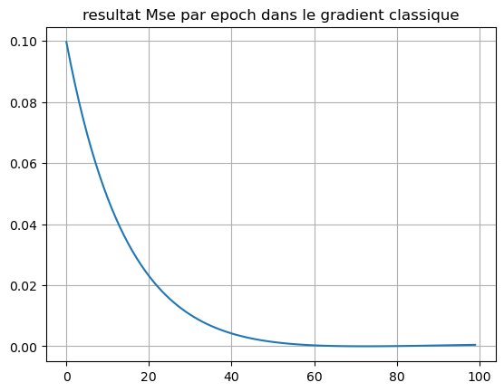

```python
# avant optimisation (full batch)
epochs=100
lr=1e-2
Y_pred = forwardPropagation(Xtest, weights_by_layer, act_func)
result_sse=[]
wi=weights_by_layer.copy()
for epoch in range(epochs):
    grad= np.zeros(gradients_sample.shape)
    for i in range(100):
        _, gradients_sample = backPropagation(Xtrain[:,i:i+1], Ytrain[:,i:i+1], wi, act_func, act_func_deriv)
        grad+=gradients_sample
    x=weightsByLayerToX(wi)
    x=x-lr*(1/100)*grad
    wi=xtoWeightsByLayer(x, layerSizes)
    y_pred= forwardPropagation(Xtrain, wi, act_func)
    result_sse.append(0.5*np.mean(y_pred-Ytrain)**2)
plt.plot(range(epochs), result_sse)
plt.grid()
plt.title("resultat Mse par epoch dans le gradient classique")
plt.show()
```

```python
# resultat sur les données test
0.5 * np.mean((Ytest - forwardPropagation(Xtest, wi, act_func))**2)
```

```
0.289156198296905
```

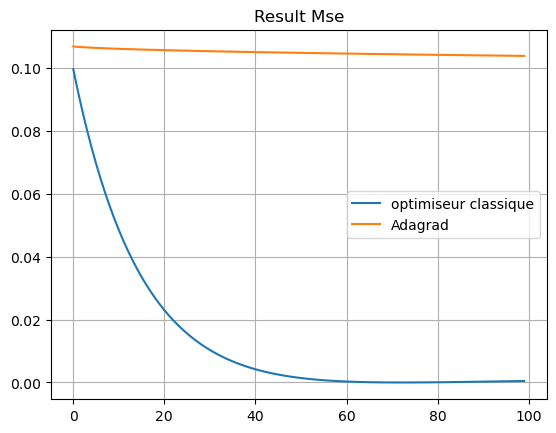

```python
# Initialize sum of squares of gradients for Adagrad
sum_squares = np.zeros_like(weightsByLayerToX(weights_by_layer))
epsilon = 1e-8
lr=1e-2
result_sse1=[]
wi=weights_by_layer.copy()
# Training loop with Adagrad optimizer
for epoch in range(epochs):
    grad = np.zeros_like(sum_squares)
    for i in range(100):
        _, gradients_sample = backPropagation(Xtrain[:, i:i+1], Ytrain[:, i:i+1], wi, act_func, act_func_deriv)
        grad+=gradients_sample
    # Adagrad update
    sum_squares += grad ** 2
    x = weightsByLayerToX(wi)
    x -= lr * (1/100) * grad / (np.sqrt((sum_squares) + epsilon))  # Adagrad adjustment

    wi = xtoWeightsByLayer(x, layerSizes)
    y_pred = forwardPropagation(Xtrain, wi, act_func)
    result_sse1.append(0.5 * np.mean(y_pred - Ytrain) ** 2)

plt.plot(range(epochs), result_sse, label="optimiseur classique")
plt.plot(range(epochs), result_sse1, label="Adagrad")
plt.legend()
plt.grid()
plt.title("Result Mse")
plt.show()
```

```python
# resultat sur les données test
0.5 * np.mean((Ytest - forwardPropagation(Xtest, wi, act_func))**2)
```

```
0.4964968542636238
```

Une faible performance sur les données train induira bien sûr une faible performance sur les données test.

Dans le cas full batch, l'optimiseur Adagrad a été plus lent que l'optimiseur classique.

essayons de varier les learning rates que ça soit pour Adagrad ou l'autre optimiseur.

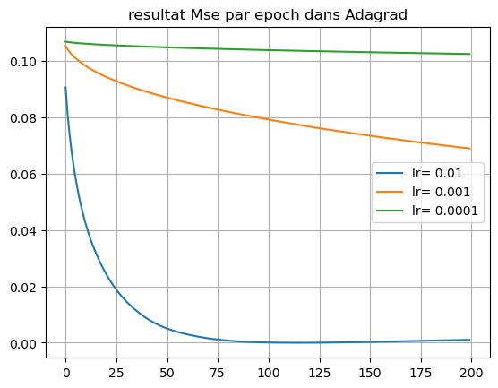

```python
epochs=200
best_weights= weights_by_layer.copy()
for lr in [10**(-i) for i in range(2,5)]:
    sum_squares = np.zeros_like(weightsByLayerToX(weights_by_layer))
    epsilon = 1e-8
    result_sse1=[]
    wi=weights_by_layer.copy()
    # Training loop with Adagrad optimizer
    for epoch in range(epochs):
        grad = np.zeros_like(sum_squares)
        for i in range(100):
            _, gradients_sample = backPropagation(Xtrain[:, i:i+1], Ytrain[:, i:i+1], wi, act_func, act_func_deriv)
            grad+=gradients_sample
        # Adagrad update
        sum_squares += ((1/100)*grad)**2
        x = weightsByLayerToX(wi)
        x -= lr * (1/100) * grad / (np.sqrt(sum_squares + epsilon))  # Adagrad adjustment

        wi = xtoWeightsByLayer(x, layerSizes)
        y_pred = forwardPropagation(Xtrain, wi, act_func)
        result_sse1.append(0.5 * np.mean(y_pred - Ytrain) ** 2)
        if len(result_sse1)>1 and result_sse1[-1]<result_sse1[-2]:
            best_weights= wi
    plt.plot(range(epochs), result_sse1, label= "lr= "+str(lr))
plt.legend()
plt.title("resultat Mse par epoch dans Adagrad")
plt.grid()
plt.show()
```

```python
# resultat sur les données test
0.5 * np.mean((Ytest - forwardPropagation(Xtest, best_weights, act_func))**2) # meilleur résultat avec Adagrad
```

```
0.49472264963930146
```

La convergence vers $W^{*}$ est plus rapide si le learning rate est élevé.

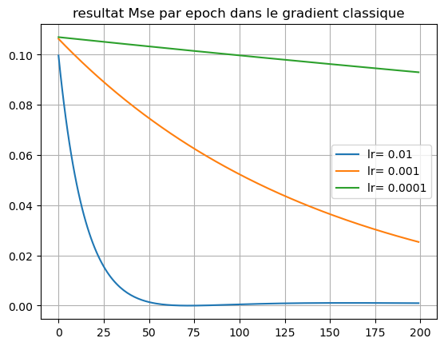

```python
epochs=200
best_weights= weights_by_layer.copy()
bestse=np.inf
for lr in [10**(-i) for i in range(2,5)]:
    result_sse=[]
    wi=weights_by_layer.copy()
    for epoch in range(epochs):
        grad= np.zeros(gradients_sample.shape)
        for i in range(100):
            _, gradients_sample = backPropagation(Xtrain[:,i:i+1], Ytrain[:,i:i+1], wi, act_func, act_func_deriv)
            grad+=gradients_sample
        x=weightsByLayerToX(wi)
        x=x-lr*(1/100)*grad
        wi=xtoWeightsByLayer(x, layerSizes)
        y_pred= forwardPropagation(Xtrain, wi, act_func)
        result_sse.append(0.5*np.mean(y_pred-Ytrain)**2)
        if 0.5*np.mean(y_pred-Ytrain)**2 < bestse:
            bestse= 0.5*np.mean(y_pred-Ytrain)**2
            best_weights= wi
    plt.plot(range(epochs), result_sse, label= "lr= "+str(lr))
plt.grid()
plt.legend()
plt.title("resultat Mse par epoch dans le gradient classique")
plt.show()
```

```python
# resultat sur les données test
0.5 * np.mean((Ytest - forwardPropagation(Xtest, best_weights, act_func))**2) # meilleur résultat avec le gradient classique
```

```
0.301991057572833
```

La convergence pour Adagrad est moins rapide que l'optimiseur classique en géneral.

Essayons Adagrad dans le cas stochastique.

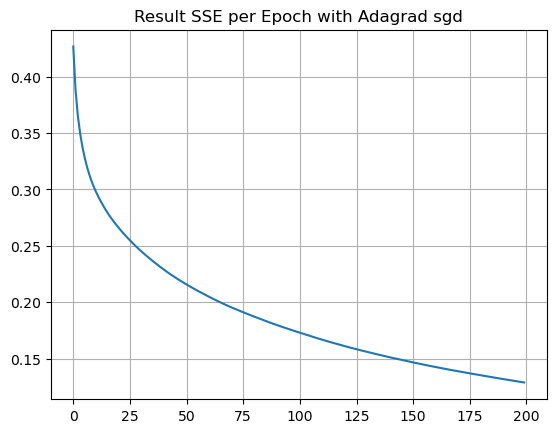

```python
sum_squares = np.zeros_like(weightsByLayerToX(weights_by_layer))
epsilon = 1e-8
lr=1e-2
result_sse2=[]
wi=weights_by_layer.copy()
for epoch in range(epochs):
    for i in range(Xtrain.shape[1]):
        _, gradients_sample = backPropagation(Xtrain[:, i:i+1], Ytrain[:, i:i+1], wi, act_func, act_func_deriv)
        grad= gradients_sample
        # Adagrad update
        sum_squares += grad ** 2
        x = weightsByLayerToX(wi)
        x -= lr * grad / (np.sqrt(sum_squares + epsilon))

        wi = xtoWeightsByLayer(x, layerSizes)

    # Compute loss after epoch
    y_pred = forwardPropagation(Xtrain, wi, act_func)
    result_sse2.append(0.5 * np.mean((y_pred - Ytrain) ** 2))

# Plotting
plt.plot(range(epochs), result_sse2)
plt.grid()
plt.title("Result SSE per Epoch with Adagrad sgd")
plt.show()
```

```python
# resultat sur les données test
0.5 * np.mean((Ytest - forwardPropagation(Xtest, wi, act_func))**2)
```

```
0.1490546538795816
```

On a obtenu des meilleurs résultats par la descente stochastique.

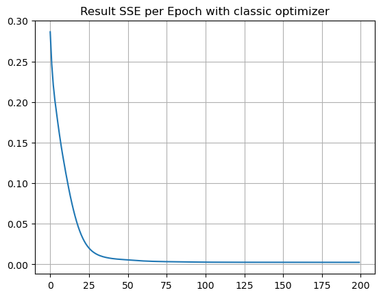

```python
sum_squares = np.zeros_like(weightsByLayerToX(weights_by_layer))
epsilon = 1e-8
lr=1e-2
result_sse2=[]
wi=weights_by_layer.copy()
for epoch in range(epochs):
    for i in range(Xtrain.shape[1]):
        _, gradients_sample = backPropagation(Xtrain[:, i:i+1], Ytrain[:, i:i+1], wi, act_func, act_func_deriv)
        grad= gradients_sample
        sum_squares += grad ** 2
        x = weightsByLayerToX(wi)
        x -= lr * grad

        wi = xtoWeightsByLayer(x, layerSizes)

    # Compute loss after epoch
    y_pred = forwardPropagation(Xtrain, wi, act_func)
    result_sse2.append(0.5 * np.mean((y_pred - Ytrain) ** 2))

# Plotting
plt.plot(range(epochs), result_sse2)
plt.grid()
plt.title("Result SSE per Epoch with classic optimizer")
plt.show()
```

```python
# resultat sur les données test
0.5 * np.mean((Ytest - forwardPropagation(Xtest, wi, act_func))**2)
```

```
0.0033855963510188293
```

La descente stochastique a encore obtenu des resultats meilleurs avec le gradient classique.

Pour étudier dans la suite l'effet de la taille des batchs, et sachant qu'on a que 100 échantillons dans le full batch, on prendra comme longuers de mini-batches 1(stochastique), 5, 25, 100(déterministe) pour avoir une vision plus profonde sur l'effet de la taille des batchs.

Commençons par l'optimizeur classique.

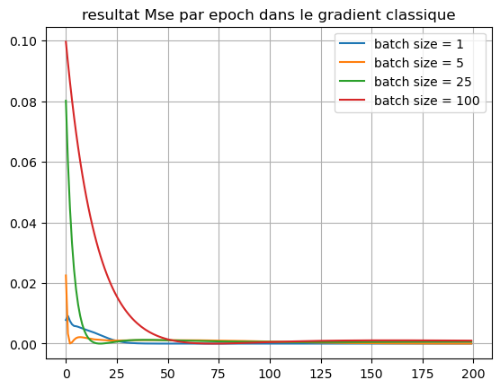

```python
batch_sizes=[1,5,25,100]
lr=1e-2
epochs=200
wi=weights_by_layer.copy()
best_weights=weights_by_layer.copy()
bestsse=np.inf
for batch_size in batch_sizes:
    result_sse=[]
    wi=weights_by_layer.copy()
    for epoch in range(epochs):
        it=0
        while it+batch_size<=Xtrain.shape[1]:
            grad= np.zeros(gradients_sample.shape)
            for i in range(it, it+batch_size):
                _, gradients_sample = backPropagation(Xtrain[:,i:i+1], Ytrain[:,i:i+1], wi, act_func, act_func_deriv)
                grad+=gradients_sample
            x=weightsByLayerToX(wi)
            x=x-lr*(1/batch_size)*grad
            wi=xtoWeightsByLayer(x, layerSizes)
            it+=batch_size
        y_pred= forwardPropagation(Xtrain, wi, act_func)
        result_sse.append(0.5*np.mean(y_pred-Ytrain)**2)
        if 0.5*np.mean(y_pred-Ytrain)**2 < bestsse:
            bestsse= 0.5*np.mean(y_pred-Ytrain)**2
            best_weights= wi
    plt.plot(range(epochs), result_sse, label="batch size = "+str(batch_size))
plt.grid()
plt.legend()
plt.title("resultat Mse par epoch dans le gradient classique")
plt.show()
```

```python
# resultat sur les données test
0.5 * np.mean((Ytest - forwardPropagation(Xtest, wi, act_func))**2)
```

```
0.26444887893667013
```

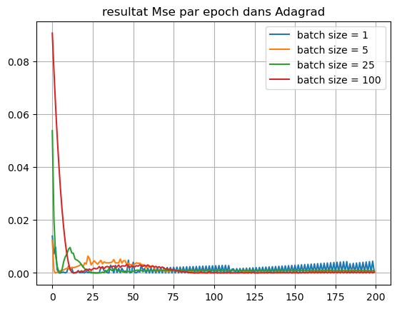

```python
batch_sizes=[1,5,25,100]
lr=1e-2
epochs=200
wi=weights_by_layer.copy()
best_weights=weights_by_layer.copy()
bestsse=np.inf
for batch_size in batch_sizes:
    result_sse=[]
    wi=weights_by_layer.copy()
    for epoch in range(epochs):
        it=0
        while it+batch_size<=Xtrain.shape[1]:
            sum_squares = np.zeros_like(weightsByLayerToX(weights_by_layer))
            grad= np.zeros(gradients_sample.shape)
            for i in range(it, it+batch_size):
                _, gradients_sample = backPropagation(Xtrain[:,i:i+1], Ytrain[:,i:i+1], wi, act_func, act_func_deriv)
                grad+=gradients_sample
            sum_squares += ((1/batch_size)*grad) ** 2
            x=weightsByLayerToX(wi)
            x=x-lr*(1/batch_size)*grad/np.sqrt(sum_squares + epsilon)
            wi=xtoWeightsByLayer(x, layerSizes)
            it+=batch_size
        y_pred= forwardPropagation(Xtrain, wi, act_func)
        result_sse.append(0.5*np.mean(y_pred-Ytrain)**2)
        if 0.5*np.mean(y_pred-Ytrain)**2 < bestsse:
            bestsse= 0.5*np.mean(y_pred-Ytrain)**2
            best_weights= wi
    plt.plot(range(epochs), result_sse, label="batch size = "+str(batch_size))
plt.grid()
plt.legend()
plt.title("resultat Mse par epoch dans Adagrad")
plt.show()
```

```python
# resultat sur les données test
0.5 * np.mean((Ytest - forwardPropagation(Xtest, wi, act_func))**2)
```

```
0.005176693062144694
```

En géneral, Adagrad a produit beacoup de bruit par rapport à l'optimiseur classique, ce bruit dimmunue de plus en ples la taille de batch augmente.

Après un grand nombre d'epochs, le bruit bruit de convergence dimminue dans Adagrad avec l'augmentation de la taille des batches.

On peut aller plus loin et étudier l'effet de nombre d'activations dans le hidden layer sur l'erreur, mais ceci est plus couteux computationnelement. En plus si on voulait construire notre modèle optimale, on a besoin d'étudier l'effet croisé de ces hyperparamètres, ce qui résultera dans plusieurs boucles. Pour se contourner à ce problème, La méthode Bayesian Optimisation est utilisée pour trouver le modèle avec les meilleurs hyerparamètres sans subir le cout si on le fera from scratch.

Pour implémenter une telle méthode prédefinit avec les réseaux de neurones dans Python, on récréera notre réseau à l'aide de TensorFlow.

### Recherche du modèle optimale pour la fonction quadratique :

Avant de procéder créeons un échantillon de données plus grand.

```python
import random
import numpy as np
import matplotlib.pyplot as plt
d = 2
LB = -5 * np.ones(d)
UB = 5 * np.ones(d)
ntrain = 300
ntest = 50
ndata = ntrain + ntest

np.random.seed(1)
rawX = np.random.uniform(low=LB, high=UB, size=(ndata, d))

random.seed()

rawYobs = np.apply_along_axis(quadratic, 1, rawX)

# normalize the data
X = normByRow(rawX)
Yobs = normByRow(rawYobs.reshape(-1, 1))

# Split into training and testing sets
itrain = np.arange(ntrain)
itest = np.arange(ntrain, ndata)
Xtrain = X['dat'][itrain, :].T
Xtest = X['dat'][itest, :].T
Ytrain = Yobs['dat'][itrain, :].T
Ytest = Yobs['dat'][itest, :].T
```

```python
Xtrain.shape
```

```
(2, 300)
```

```python
import tensorflow as tf
from tensorflow.keras.models import Sequential
from tensorflow.keras.layers import Dense
from kerastuner.tuners import BayesianOptimization

model = Sequential([
    Dense(3, input_shape=(2,), activation='relu'),  # Input layer with 2 neurons, hidden layer with 3 neurons
    Dense(1, activation='linear')  # Output layer with 1 neuron
])
model.compile(optimizer='adam', loss='mean_squared_error', metrics=['mean_squared_error'])
```

[output not shown]

[output not shown]

[output not shown]

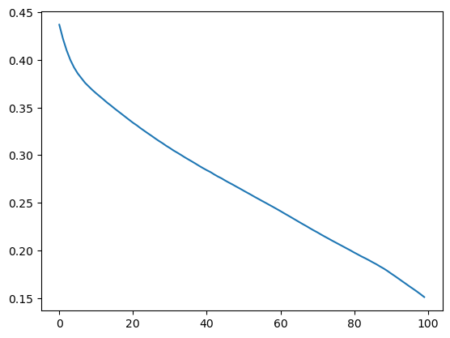

```python
history = model.fit(Xtrain.T, Ytrain.T, epochs=100, batch_size=32, verbose=0)
plt.plot(history.history['mean_squared_error'])
```

il s'agit ci dessus de l'evolution de MSE par epoch, elle est très semblable à la notre.

```python
test_loss, test_mae = model.evaluate(Xtest.T, Ytest.T)
print(f"Test Loss: " ,test_loss)
```

```
Test Loss:  0.16638801991939545
```

```python
import tensorflow as tf
from tensorflow.keras.models import Sequential
from tensorflow.keras.layers import Dense
from kerastuner.tuners import BayesianOptimization
import numpy as np
import matplotlib.pyplot as plt
```

```python
def build_model(hp):
    model = Sequential()
    model.add(Dense(units=hp.Int('units', min_value=1, max_value=10, step=1),
                    activation=hp.Choice('activation', values=['relu', 'tanh', 'sigmoid']),
                    input_shape=(2,)))
    model.add(Dense(1, activation='linear'))
    model.compile(
        optimizer=tf.keras.optimizers.Adam(
            hp.Float('learning_rate', min_value=1e-4, max_value=1e-2, sampling='LOG')),
        loss='mean_squared_error',
        metrics=['mean_squared_error'])
    return model
```

```python
tuner = BayesianOptimization(
    build_model,
    objective='val_mean_squared_error',
    max_trials=10,
    directory='my_dir',
    project_name='hparam_tuning'
)
```

```
Reloading Tuner from my_dir\hparam_tuning\tuner0.json
```

```python
tuner.search(Xtrain.T, Ytrain.T, epochs=10, validation_data=(Xtest.T, Ytest.T))
```

```python
# Get the optimal hyperparameters
best_hps = tuner.get_best_hyperparameters(num_trials=1)[0]

print(f"""
optimal number of units in the hidden  layer is {best_hps.get('units')},
the optimal activation function is {best_hps.get('activation')},
and the optimal learning rate for the optimizer is {best_hps.get('learning_rate')}.
""")
```

```
optimal number of units in the hidden  layer is 4,
the optimal activation function is relu,
and the optimal learning rate for the optimizer is 0.007533407699736988.
```

```python
# Build the model with the best hyperparameters and train it on the data
model = tuner.hypermodel.build(best_hps)
history = model.fit(Xtrain.T, Ytrain.T, epochs=200, validation_data=(Xtest.T, Ytest.T))
```

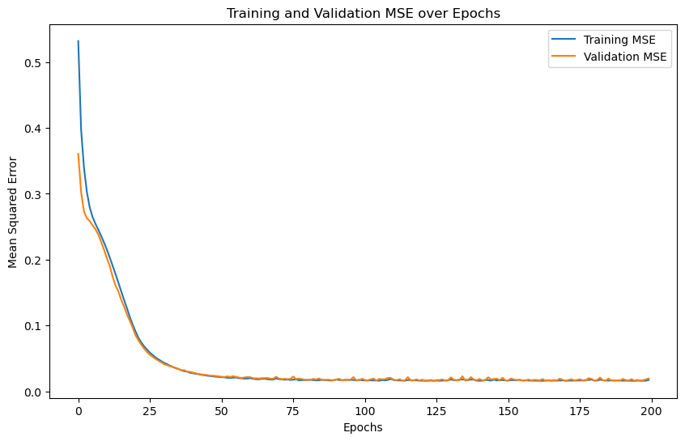

```python
plt.figure(figsize=(10, 6))
plt.plot(history.history['mean_squared_error'], label='Training MSE')
plt.plot(history.history['val_mean_squared_error'], label='Validation MSE')
plt.title('Training and Validation MSE over Epochs')
plt.xlabel('Epochs')
plt.ylabel('Mean Squared Error')
plt.legend()
plt.show()
```

```python
test_loss, test_mae = model.evaluate(Xtest.T, Ytest.T)
print(f"Test Loss: " ,test_loss)
```

```
Test Loss:  0.019464679062366486
```

# Utilisons maintenant une autre fonction: schwefel

On visualise la fonction:

[figure not shown]

```python
import matplotlib.pyplot as plt
from mpl_toolkits.mplot3d import Axes3D

def schwefel(xx, get_glob_xstar=False):
    glob_xstar = np.full_like(xx, 3.209687)
    if get_glob_xstar:
        return glob_xstar
    else:
        xx = xx + 1
        aa = 100 * xx
        d = len(aa)
        sum_val = 418.9829 * d - np.sum(aa * np.sin(np.sqrt(np.abs(aa))))
        return sum_val

# Create a meshgrid of input values
x = np.linspace(-5, 5, 100)
y = np.linspace(-5, 5, 100)
x1, x2 = np.meshgrid(x, y)

# Compute the function values
z = np.array([schwefel(np.array([x, y])) for x, y in zip(np.ravel(x1), np.ravel(x2))])
z = z.reshape(x1.shape)

# Plot
fig = plt.figure()
ax = fig.add_subplot(111, projection='3d')
ax.plot_surface(x1, x2, z, cmap='viridis')

ax.set_xlabel('X1 Axis')
ax.set_ylabel('X2 Axis')
ax.set_zlabel('Tunnel Function Value')

plt.title('3D Plot of the Tunnel Function')
plt.show()
```

On génere les données train et test:

```python
import random


d = 2
LB = -5 * np.ones(d)
UB = 5 * np.ones(d)
ntrain = 100
ntest = 15
ndata = ntrain + ntest

np.random.seed(1)
rawX = np.random.uniform(low=LB, high=UB, size=(ndata, d))

random.seed()

rawYobs = np.apply_along_axis(schwefel, 1, rawX)

# normalize the data
X = normByRow(rawX)
Yobs = normByRow(rawYobs.reshape(-1, 1))

# Split into training and testing sets
itrain = np.arange(ntrain)
itest = np.arange(ntrain, ndata)
Xtrain1 = X['dat'][itrain, :].T
Xtest1 = X['dat'][itest, :].T
Ytrain1 = Yobs['dat'][itrain, :].T
Ytest1 = Yobs['dat'][itest, :].T
```

```python
# Initializing neural network parameters
np.random.seed(1)
layerSizes = [2, 3, 1]
weights_by_layer = createRandomWeightsByLayer(layerSizes)
act_func = [[relu, relu, relu], [linear]]
act_func_deriv = [[reluDeriv, reluDeriv, reluDeriv], [linearDeriv]]
```

On entraine le modèle par l'optimiseur Adagrad :

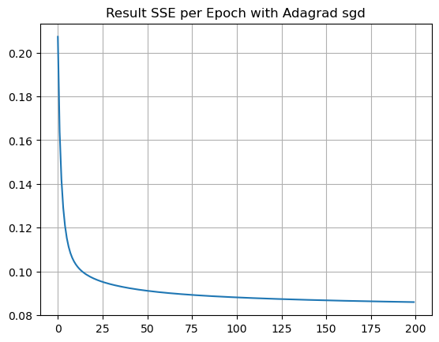

```python
sum_squares = np.zeros_like(weightsByLayerToX(weights_by_layer))
epsilon = 1e-8
lr=1e-2
result_sse2=[]
wi_Adagrad=weights_by_layer.copy()
for epoch in range(epochs):
    for i in range(Xtrain1.shape[1]):
        _, gradients_sample = backPropagation(Xtrain1[:, i:i+1], Ytrain1[:, i:i+1], wi_Adagrad, act_func, act_func_deriv)
        grad= gradients_sample
        # Adagrad update
        sum_squares += grad ** 2
        x = weightsByLayerToX(wi_Adagrad)
        x -= lr * grad / (np.sqrt(sum_squares + epsilon))

        wi_Adagrad = xtoWeightsByLayer(x, layerSizes)

    # Compute loss after epoch
    y_pred = forwardPropagation(Xtrain1, wi_Adagrad, act_func)
    result_sse2.append(0.5 * np.mean((y_pred - Ytrain1) ** 2))

# Plotting
plt.plot(range(epochs), result_sse2)
plt.grid()
plt.title("Result SSE per Epoch with Adagrad sgd")
plt.show()
```

Testons le modèle sur les données Test :

```python
y_pred_Adagrad = forwardPropagation(Xtest1,wi_Adagrad, act_func)
0.5 * np.mean((y_pred_Adagrad - Ytest1) ** 2)
```

```
0.14095636550044113
```

Essayant maintenant avec l'optimiseur Adam (from scratch):

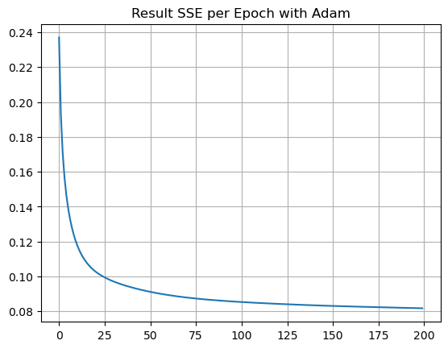

```python
# Initialisation pour Adam
m = np.zeros_like(weightsByLayerToX(weights_by_layer))
v = np.zeros_like(weightsByLayerToX(weights_by_layer))
epsilon = 1e-8
lr = 1e-3
beta1 = 0.9
beta2 = 0.999

result_sse2 = []
wi_adam = weights_by_layer.copy()

for epoch in range(epochs):
    for i in range(Xtrain1.shape[1]):
        _, gradients_sample = backPropagation(Xtrain1[:, i:i+1], Ytrain1[:, i:i+1], wi_adam, act_func, act_func_deriv)
        grad = gradients_sample

        # Mise à jour avec Adam
        m = beta1 * m + (1 - beta1) * grad
        v = beta2 * v + (1 - beta2) * (grad ** 2)
        m_hat = m / (1 - beta1 ** (epoch + 1))
        v_hat = v / (1 - beta2 ** (epoch + 1))

        x = weightsByLayerToX(wi_adam)
        x -= lr * m_hat / (np.sqrt(v_hat) + epsilon)

        wi_adam = xtoWeightsByLayer(x, layerSizes)

    # Compute loss after epoch
    y_pred = forwardPropagation(Xtrain1, wi_adam, act_func)
    result_sse2.append(0.5 * np.mean((y_pred - Ytrain1) ** 2))

# Plotting
plt.plot(range(epochs), result_sse2)
plt.grid()
plt.title("Result SSE per Epoch with Adam")
plt.show()
```

Testons maintenant ce modèle sur les données Test:

```python
y_pred_adam = forwardPropagation(Xtest1, wi_adam, act_func)
0.5 * np.mean((y_pred_adam - Ytest1) ** 2)
```

```
0.13468179432315702
```

On peut observer que l'optimiseur Adam génère une erreur sur l'ensemble de test inférieure à celle obtenue avec l'optimiseur Adagrad. Maintenant cherchons à optimiser ses paramètres beta1 et beta2.

```python
import numpy as np

# Grilles de recherche
beta1_values = [0.85, 0.9, 0.95]
beta2_values = [0.990, 0.995, 0.999]


best_beta1 = 0
best_beta2 = 0
lowest_error = np.inf

# Boucle sur les valeurs de beta1 et beta2
for beta1 in beta1_values:
    for beta2 in beta2_values:
        m = np.zeros_like(weightsByLayerToX(weights_by_layer))
        v = np.zeros_like(weightsByLayerToX(weights_by_layer))
        wi_adam = weights_by_layer.copy()
        result_sse2 = []

        for epoch in range(epochs):
            for i in range(Xtrain1.shape[1]):
                _, gradients_sample = backPropagation(Xtrain1[:, i:i+1], Ytrain1[:, i:i+1], wi_adam, act_func, act_func_deriv)
                grad = gradients_sample

                # Mise à jour avec Adam
                m = beta1 * m + (1 - beta1) * grad
                v = beta2 * v + (1 - beta2) * (grad ** 2)
                m_hat = m / (1 - beta1 ** (epoch + 1))
                v_hat = v / (1 - beta2 ** (epoch + 1))

                x = weightsByLayerToX(wi_adam)
                x -= lr * m_hat / (np.sqrt(v_hat) + epsilon)

                wi_adam = xtoWeightsByLayer(x, layerSizes)

            # Compute loss after epoch
            y_pred = forwardPropagation(Xtrain1, wi_adam, act_func)
            result_sse2.append(0.5 * np.mean((y_pred - Ytrain1) ** 2))

        # Enregistrement de la meilleure performance
        final_error = result_sse2[-1]
        if final_error < lowest_error:
            lowest_error = final_error
            best_beta1 = beta1
            best_beta2 = beta2

# Afficher les meilleurs paramètres
print("Meilleurs beta1 et beta2:", best_beta1, best_beta2, "avec une erreur de:", lowest_error)
```

```
Meilleurs beta1 et beta2: 0.95 0.99 avec une erreur de: 0.07832533488559591
```

Essayant alors ces paramètres à nouveau:

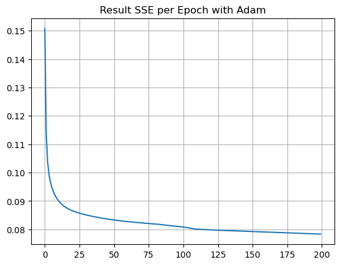

```python
# Initialisation pour Adam
m = np.zeros_like(weightsByLayerToX(weights_by_layer))
v = np.zeros_like(weightsByLayerToX(weights_by_layer))
epsilon = 1e-8
lr = 1e-3
beta1 = 0.95
beta2 = 0.99

result_sse2 = []
wi_adam_opt = weights_by_layer.copy()

for epoch in range(epochs):
    for i in range(Xtrain1.shape[1]):
        _, gradients_sample = backPropagation(Xtrain1[:, i:i+1], Ytrain1[:, i:i+1], wi_adam_opt, act_func, act_func_deriv)
        grad = gradients_sample

        # Mise à jour avec Adam
        m = beta1 * m + (1 - beta1) * grad
        v = beta2 * v + (1 - beta2) * (grad ** 2)
        m_hat = m / (1 - beta1 ** (epoch + 1))
        v_hat = v / (1 - beta2 ** (epoch + 1))

        x = weightsByLayerToX(wi_adam_opt)
        x -= lr * m_hat / (np.sqrt(v_hat) + epsilon)

        wi_adam_opt = xtoWeightsByLayer(x, layerSizes)

    # Compute loss after epoch
    y_pred = forwardPropagation(Xtrain1, wi_adam_opt, act_func)
    result_sse2.append(0.5 * np.mean((y_pred - Ytrain1) ** 2))

# Plotting
plt.plot(range(epochs), result_sse2)
plt.grid()
plt.title("Result SSE per Epoch with Adam")
plt.show()
```

```python
y_pred_adam = forwardPropagation(Xtest1, wi_adam_opt, act_func)
0.5 * np.mean((y_pred_adam - Ytest1) ** 2)
```

```
0.12793349249369584
```

Donc on peut bien voir que l'erreur a bien diminuée avec les paramètres optimaux de Adam.

La recherche précédente des paramètres beta1 et beta2 était assez exhaustive. Nous allons maintenant comparer notre modèle en utilisant l'optimiseur Adam prédéfini dans la bibliothèque Keras.

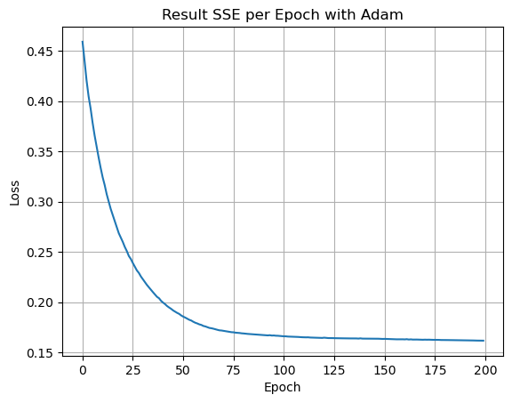

```
Test Loss: 0.27665865421295166
```

```python
import tensorflow as tf
from tensorflow.keras.models import Sequential
from tensorflow.keras.layers import Dense
from tensorflow.keras.optimizers import Adam

# Création du modèle
model = Sequential([
    # Ajoutez vos couches ici en fonction de la structure de votre réseau
    Dense(units=3, activation='relu', input_shape=(2,)),
    Dense(units=1, activation='linear')
])

# Configuration de l'optimiseur Adam
optimizer = Adam(learning_rate=1e-3, beta_1=0.95, beta_2=0.99, epsilon=1e-8)

# Compilation du modèle
model.compile(optimizer=optimizer, loss='mean_squared_error')

# Entraînement du modèle
history = model.fit(Xtrain1.T, Ytrain1.T, epochs=epochs, batch_size=10)

# Évaluation du modèle sur les données de test
test_loss = model.evaluate(Xtest1.T, Ytest1.T)

# Visualisation de la perte au cours de l'entraînement
plt.plot(history.history['loss'])
plt.title('Result SSE per Epoch with Adam')
plt.ylabel('Loss')
plt.xlabel('Epoch')
plt.grid()
plt.show()

# Affichage de la perte sur le jeu de test
print("Test Loss:", test_loss)
```

On peut bien voir qu'avec la même initialisation du réseau de neurones, nous obtenons une erreur plus grande que celle précédemment trouvée. Essayons maintenant d'optimiser les paramètres de ce modèle, notamment le taux d'apprentissage (learning rate) et le nombre d'activations.

```python
import numpy as np
import tensorflow as tf
from tensorflow.keras.models import Sequential
from tensorflow.keras.layers import Dense
from tensorflow.keras.optimizers import Adam
from sklearn.model_selection import KFold


learning_rates = [1e-4, 1e-3, 1e-2]
neuron_numbers = [5, 10, 15]  # Nombre de neurones dans la couche cachée


best_lr = None
best_neurons = None
best_loss = np.inf

# Utiliser la validation croisée pour évaluer chaque combinaison
for lr in learning_rates:
    for neurons in neuron_numbers:
        # Création du modèle
        model = Sequential([
            Dense(units=neurons, activation='relu', input_shape=(2,)),
            Dense(units=1, activation='linear')
        ])

        # Configuration de l'optimiseur Adam avec le taux d'apprentissage courant
        optimizer = Adam(learning_rate=lr)

        # Compilation du modèle
        model.compile(optimizer=optimizer, loss='mean_squared_error')

        # Entraînement et évaluation avec validation croisée
        kf = KFold(n_splits=2)
        avg_loss = 0
        for train_index, test_index in kf.split(Xtrain1.T):
            X_train, X_val = Xtrain1.T[train_index], Xtrain1.T[test_index]
            Y_train, Y_val = Ytrain1.T[train_index], Ytrain1.T[test_index]

            history = model.fit(X_train, Y_train, epochs=100, batch_size=10, verbose=0)
            loss = model.evaluate(X_val, Y_val, verbose=0)
            avg_loss += loss / 2

        # Mise à jour des meilleurs paramètres si nécessaire
        if avg_loss < best_loss:
            best_loss = avg_loss
            best_lr = lr
            best_neurons = neurons

# Affichage des meilleurs paramètres
print(f'Meilleur taux d\'apprentissage: {best_lr}, Meilleur nombre de neurones: {best_neurons}, Perte: {best_loss}')
```

```
WARNING:tensorflow:5 out of the last 412 calls to <function Model.make_test_function.<locals>.test_function at 0x0000028BCB9FE0C0> triggered tf.function retracing. Tracing is expensive and the excessive number of tracings could be due to (1) creating @tf.function repeatedly in a loop, (2) passing te…
Meilleur taux d'apprentissage: 0.001, Meilleur nombre de neurones: 15, Perte: 0.1795143559575081
```

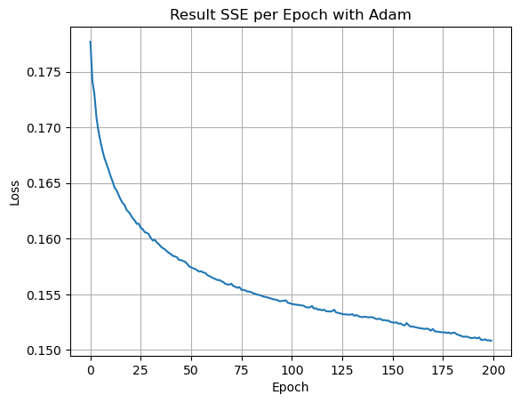

```
Test Loss: 0.2540830373764038
```

```python
# Création du modèle
model = Sequential([
    # Ajoutez vos couches ici en fonction de la structure de votre réseau
    Dense(units=5, activation='relu', input_shape=(2,)),
    Dense(units=1, activation='linear')
])

# Configuration de l'optimiseur Adam
optimizer = Adam(learning_rate=1e-3, beta_1=0.95, beta_2=0.99, epsilon=1e-8)

# Compilation du modèle
model.compile(optimizer=optimizer, loss='mean_squared_error')

# Entraînement du modèle
history = model.fit(Xtrain1.T, Ytrain1.T, epochs=epochs, batch_size=10)

# Évaluation du modèle sur les données de test
test_loss = model.evaluate(Xtest1.T, Ytest1.T)

# Visualisation de la perte au cours de l'entraînement
plt.plot(history.history['loss'])
plt.title('Result SSE per Epoch with Adam')
plt.ylabel('Loss')
plt.xlabel('Epoch')
plt.grid()
plt.show()

# Affichage de la perte sur le jeu de test
print("Test Loss:", test_loss)
```

L'erreur a été bien diminuée par rapport au dernier modèle.

# Réseau de neurones et SVM

## a. Des données presque linéairement séparables

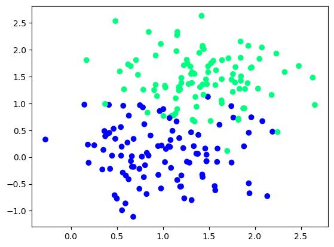

```python
from sklearn.datasets import make_blobs

# Générer des données avec make_blobs
X, y = make_blobs(n_samples=200, n_features=2, centers=[[1, 0], [1.5, 1.5]], cluster_std=0.5, random_state=0)

# Afficher les points pour chaque classe
plt.scatter(X[:, 0], X[:, 1], c = y, cmap = 'winter' )


plt.show()
```

#### a.1 Création d'un réseau de neurone :

Le réseau adapté dans ce cas est le perceptron et on utilisera comme fonction d'activation la fonction sigmoid

```python
# Forward Propagation :
np.random.seed(0)
Weights = createRandomWeightsByLayer([2,1])
inputs = np.transpose(X)
z = forwardPropagation(inputs, Weights,[[sigmoid]])
np.shape(inputs)
```

```
(2, 200)
```

Création de la fonction Log loss et de sa fonction dérivée :

```python
# Fonction log loss :
def Logloss(A,y) :   # A liste des activations (des outputs du réseau)  et y liste des class_label
    return -1/len(y) * np.sum(y*np.log(A)+(1-y)*np.log(1-A))

print(Logloss(z[0],y))

def logLossDeriv(pred,x,y):
    return 1/len(y) * np.dot(np.transpose(x),pred-y).reshape(-1, 1)

# Avant d'utiliser x il faut ajouter une colonne de 1 :

x=X
n = len(x)
x = np.column_stack((x,np.ones(n)))

logLossDeriv(z[0],x,y)
```

```
0.9515880645429189
```

```
array([[ 0.36925193],
       [-0.03462668],
       [ 0.3624278 ]])
```

#### a.2 Backpropagation :

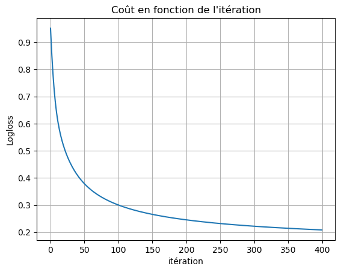

```python
def xtoWeightsByLayer(x, layerSizes = [2,7,2,1]):
    numberOfLayers = len(layerSizes) - 1
    weightsByLayer = [None] * numberOfLayers
    filledUpTo = 0

    for i in range(numberOfLayers):
        nrows = layerSizes[i] + 1
        ncols = layerSizes[i + 1]
        istart = filledUpTo + 1
        iend = filledUpTo + nrows * ncols
        filledUpTo = iend

        weightsByLayer[i] = np.reshape(x[istart - 1:iend], (nrows, ncols), order='C')

    return weightsByLayer

def weightsByLayerToX(weightsByLayer):
    x = np.array([])
    for i in range(len(weightsByLayer)):
        x = np.append(x, weightsByLayer[i].flatten(order='C'))

    return x
def Backpropagation1(x,y,Weights,learning_rate,iter,LossDeriv = logLossDeriv):
    Cost = []
    W=Weights
    s = np.transpose(x)
    n = len(s)
    s = np.column_stack((s,np.ones(n)))
    for i in range(iter) :
        z = forwardPropagation(x, W,[[sigmoid]])
        W=W[0]
        Cost.append(Logloss(z,y))
        grad = LossDeriv(z[0],s,y)
        W =  W - learning_rate * grad
        W = xtoWeightsByLayer(W, layerSizes = [2,1])

    return W , Cost



W,Cost = Backpropagation1(inputs,y,Weights,0.2,400)
plt.plot(Cost)
plt.title("Coût en fonction de l'itération")
plt.xlabel('itération')
plt.ylabel('Logloss')
plt.grid()
plt.show()
```

On voit bien que la fonction Logloss décroit, donc notre implémentation est bonne.

##### Visualisation :

```python
from sklearn.metrics import accuracy_score


def pred(W,x):
    z = forwardPropagation(x, W,[[sigmoid]])
    return z>=0.5

inputs = np.transpose(X)
y_pred = pred(W,inputs)[0]
y_pred = y_pred.astype(int)
print('accuracy_score :',accuracy_score(y_pred,y))
```

```
accuracy_score : 0.915
```

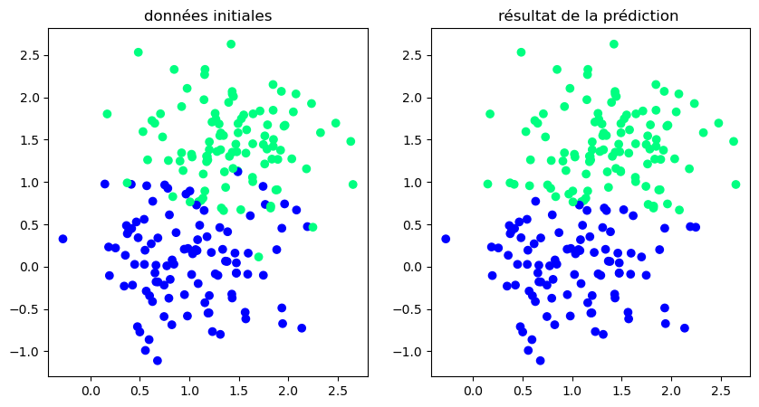

```python
fig, axs = plt.subplots(1, 2, figsize=(10, 5))
axs[0].scatter(X[:, 0], X[:, 1], c = y, cmap = 'winter' )
axs[0].set_title('données initiales')
axs[1].scatter(X[:, 0], X[:, 1], c = y_pred, cmap = 'winter' )
axs[1].set_title('résultat de la prédiction ')
plt.show()
```

```python
W,_ = Backpropagation1(inputs,y,Weights,0.2,400)
```

### Comparaison avec SVM :

```python
#import de la classe - qui s'appelle SVC et pas SVM...
from sklearn.svm import SVC
#Définition du modèle
model = SVC(kernel='linear', C=1E10)
#Apprentissage sur les donnée
model.fit(X, y)

# Prédiction des étiquettes avec le modèle entraîné
predicted_labels = model.predict(X)

# Calcul de l'accuracy_score
accuracy = accuracy_score(y, predicted_labels)
print('accuracy_score : ',accuracy)
```

```
accuracy_score :  0.9
```

Il est légerment moins bon que le model créé par le perceptron (accuracy_perceptron = 0.915 )

#### Visualisation :

```python
def affiche_fonction_de_decision(model, ax=None, plot_support=True):
    """Affiche le séparateur, les marges, et les vecteurs de support d'un SVM en 2D"""
    if ax is None:
        ax = plt.gca()
    xlim = ax.get_xlim()
    ylim = ax.get_ylim()

    # création de la grille pour l'évaluation
    x = np.linspace(xlim[0], xlim[1], 30)
    y = np.linspace(ylim[0], ylim[1], 30)
    Y, X = np.meshgrid(y, x)
    xy = np.vstack([X.ravel(), Y.ravel()]).T
    P = model.decision_function(xy).reshape(X.shape)

    # affichage de l'hyperplan et des marges
    ax.contour(X, Y, P, colors='k',
               levels=[-1, 0, 1], alpha=0.5,
               linestyles=['--', '-', '--'])

    ax.set_xlim(xlim)
    ax.set_ylim(ylim)
```

[figure not shown]

```python
# SVM à Marge souple
fig, ax = plt.subplots(1, 2, figsize=(10, 5))
fig.subplots_adjust(left=0.0625, right=0.95, wspace=0.1)

C=1e5
model = SVC(kernel='linear', C=C).fit(X, y)
ax[0].scatter(X[:, 0], X[:, 1], c=y, s=50, cmap='jet')
affiche_fonction_de_decision(model, ax[0])
ax[0].scatter(model.support_vectors_[:, 0],model.support_vectors_[:, 1],s=300, lw=1, facecolors='none');
ax[0].set_title('C = {0:.1f}'.format(C), size=14)


# On trace la frontière de décision fournit par notre réseau de neurone:
T = W[0]
T = T.reshape(1,-1)
T=T[0]
a = np.linspace(-0.3,0.3,50)
b = -(T[0]*a + T[2])/T[1]

ax[1].scatter(X[:, 0], X[:, 1], c = y, cmap = 'winter' )
ax[1].set_title('Frontière fournit par le réseau de neurones ')
ax[1].plot(a,b)
```

### b. Cas de données non linéairement séparables :

```python
def initial(n0,n1,n2):

    W1 = np.random.randn(n1,n0)
    b1 = np.random.randn(n1,1)
    W2 = np.random.randn(n2,n1)
    b2 = np.random.randn(n2,1)

    W = {
        'W1':W1,
        'b1':b1,
        'W2':W2,
        'b2':b2
    }
    return W
```

```python
def forward_propagation2(X,W):

    W1 = W['W1']
    b1 = W['b1']
    W2 = W['W2']
    b2 = W['b2']

    z1 = np.dot(W1,X) + b1
    a1 = sigmoid(z1)
    z2 = np.dot(W2,a1) + b2
    a2 = sigmoid(z2)

    act = {
        'A1':a1,
        'A2':a2
    }

    return act
```

```python
def back_propagation2(X,y,act, W):

    a1 = act['A1']
    a2 = act['A2']
    W2 = W['W2']

    m = y.shape[1]

    dZ2 = a2 - y
    dW2 = 1/m * np.dot(dZ2,a1.T)
    db2 = 1/m * np.sum(dZ2, axis = 1, keepdims = True)

    dZ1 = np.dot(W2.T,dZ2) * a1 * (1-a1)
    dW1 = 1/m * np.dot(dZ1,X.T)
    db1 = 1/m * np.sum(dZ1, axis = 1, keepdims = True)

    grad = {
        'dW1' : dW1,
        'db1' : db1,
        'dW2' : dW2,
        'db2' : db2
    }
    return grad
```

```python
def misàjour(grad,W,learning_rate):

    W1 = W['W1']
    b1 = W['b1']
    W2 = W['W2']
    b2 = W['b2']

    dW1 = grad['dW1']
    db1 = grad['db1']
    dW2 = grad['dW2']
    db2 = grad['db2']

    W1 = W1 - learning_rate * dW1
    b1 = b1 - learning_rate * db1
    W2 = W2 - learning_rate * dW2
    b2 = b2 - learning_rate * db2

    Weights = {
        'W1':W1,
        'b1':b1,
        'W2':W2,
        'b2':b2
    }

    return Weights
```

```python
def predict(X,W):
    act = forward_propagation2(X,W)
    A2 = act['A2']
    return A2 >=0.5
```

```python
def descent(X,y,n1,learning_rate,iter):

    n0 = X.shape[0]
    n2 = y.shape[0]

    Weights = initial(n0,n1,n2)

    Cost = []


    for i in range(iter):

        act = forward_propagation2(X,Weights)
        grad = back_propagation2(X,y,act,Weights)
        Weights = misàjour(grad,Weights,learning_rate)

        if i%10 == 0 :   #Batch de 10
            Cost.append(Logloss(act['A2'],y))



    plt.figure(figsize=(14,4))

    plt.plot(Cost, label='loss')
    plt.legend()

    return
```

#### Application du modèle linéaire sur les données :

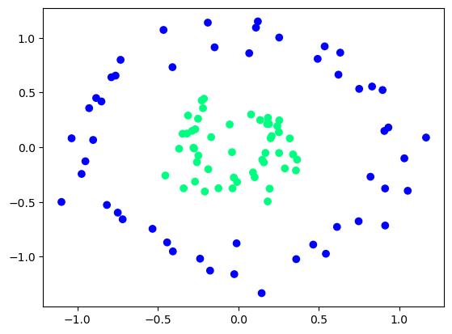

```python
from sklearn.datasets import make_circles

# Générer des données avec make_blobs
X, y = make_circles(n_samples=100, noise=0.1, factor = 0.3,random_state=0)

plt.scatter(X[:,0],X[:,1], c = y , cmap='winter')
plt.show()
```

```python
Weights = createRandomWeightsByLayer([2,1])
inputs = np.transpose(X)
W,Cost = Backpropagation1(inputs,y,Weights,0.2,400)
```

[output not shown]

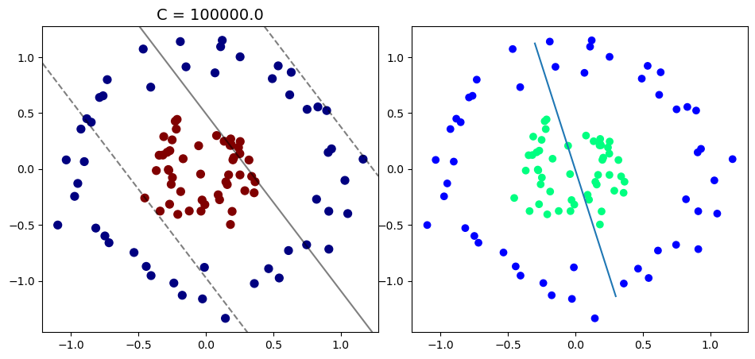

```python
# SVM à Marge souple
fig, ax = plt.subplots(1, 2, figsize=(10, 5))
fig.subplots_adjust(left=0.0625, right=0.95, wspace=0.1)

model = SVC(kernel='linear', C=C).fit(X, y)
ax[0].scatter(X[:, 0], X[:, 1], c=y, s=50, cmap='jet')
affiche_fonction_de_decision(model, ax[0])
ax[0].scatter(model.support_vectors_[:, 0],model.support_vectors_[:, 1],s=300, lw=1, facecolors='none');
ax[0].set_title('C = {0:.1f}'.format(C), size=14)


# On trace la frontière de décision fournit par notre réseau de neurone:
T = W[0]
T = T.reshape(1,-1)
T=T[0]
a = np.linspace(-0.3,0.3,50)
b = -(T[0]*a + T[2])/T[1]

ax[1].scatter(X[:, 0], X[:, 1], c = y, cmap = 'winter' )
ax[1].plot(a,b)


y_pred = pred(W,inputs)[0]
y_pred = y_pred.astype(int)
print(accuracy_score(y_pred,y))
```

#### Application du nouveau modèle aux données

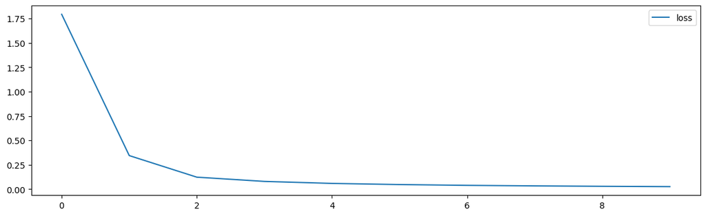

```python
y = y.reshape((y.shape[0],1))
parametres = descent(X,y,n1=2,learning_rate=0.2,iter=100)
```